# Farmington and Bear River Bay Al criteria recalculation

Jake Vander Laan

2021-02-03

# Introduction

This document demonstrates how the [EPA 2018 aluminum criterion](https://www.epa.gov/wqc/2018-final-aquatic-life-criteria-aluminum-freshwater) varies across pH, hardness, and DOC. It also pilots the application of the [species deletion procedure](https://www.epa.gov/sites/production/files/2015-08/documents/revised_deletion_process_for_the_site-specific_recalculation_procedure_for_aquatic_life_criteria.pdf) to this criterion for Farmington and Bear River Bays of Great Salt Lake, showing the potential difference between the original Al criteria and recalculated criteria based on Farmington Bay and Bear River Bay taxa. EPA published Al criterion calculator R code was wrapped into a function within the DWQs wqTools R package to facilitate the calculation of the criterion across large datasets.

# Libraries

```r
library(dplyr)
library(wqTools)
```

# Test data

Generating test data for pH (6 to 9.5), hardness (0 to 400 mg/L), and DOC (0 to 5 mg/L). This data allows application of the Al criterion calculator across a wide range of conditions to see how each factor impacts the criteria and how the impact of the species deletion procedure and recalculation across a wide range of conditions.

```r
pH=seq(6, 9.5, 0.5)
Hardness_mgL=seq(0, 400, 50)
DOC_mgL=seq(0, 5, 0.5)
test_data=merge(pH, Hardness_mgL)
names(test_data)=c('pH', 'Hardness_mgL')
test_data=merge(test_data, DOC_mgL)
names(test_data)=c('pH', 'Hardness_mgL', 'DOC_mgL')
```

# Unmodified criteria

```r
orig_crit=calcAlCrit(test_data, 'pH', 'Hardness_mgL', 'DOC_mgL')
```

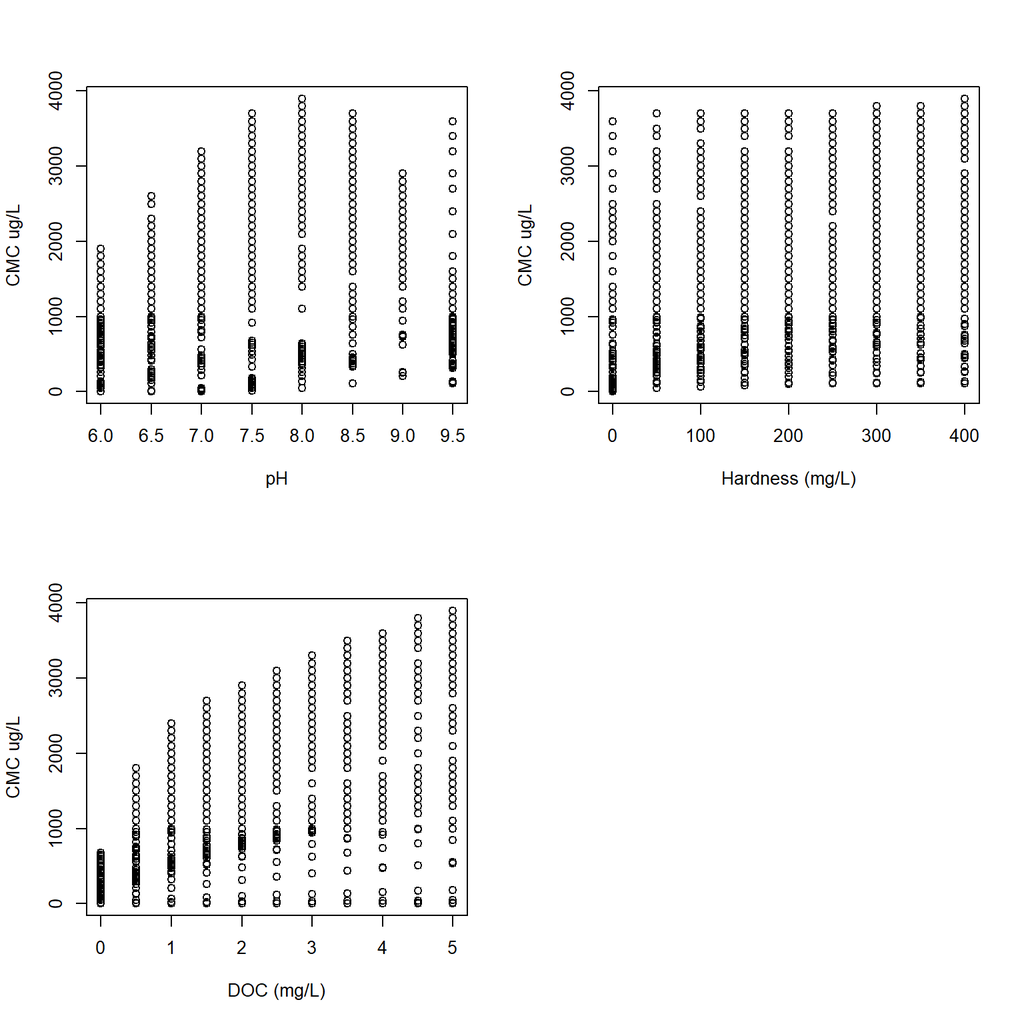

Figure 1. Unmodified CMC variability on correction factors.

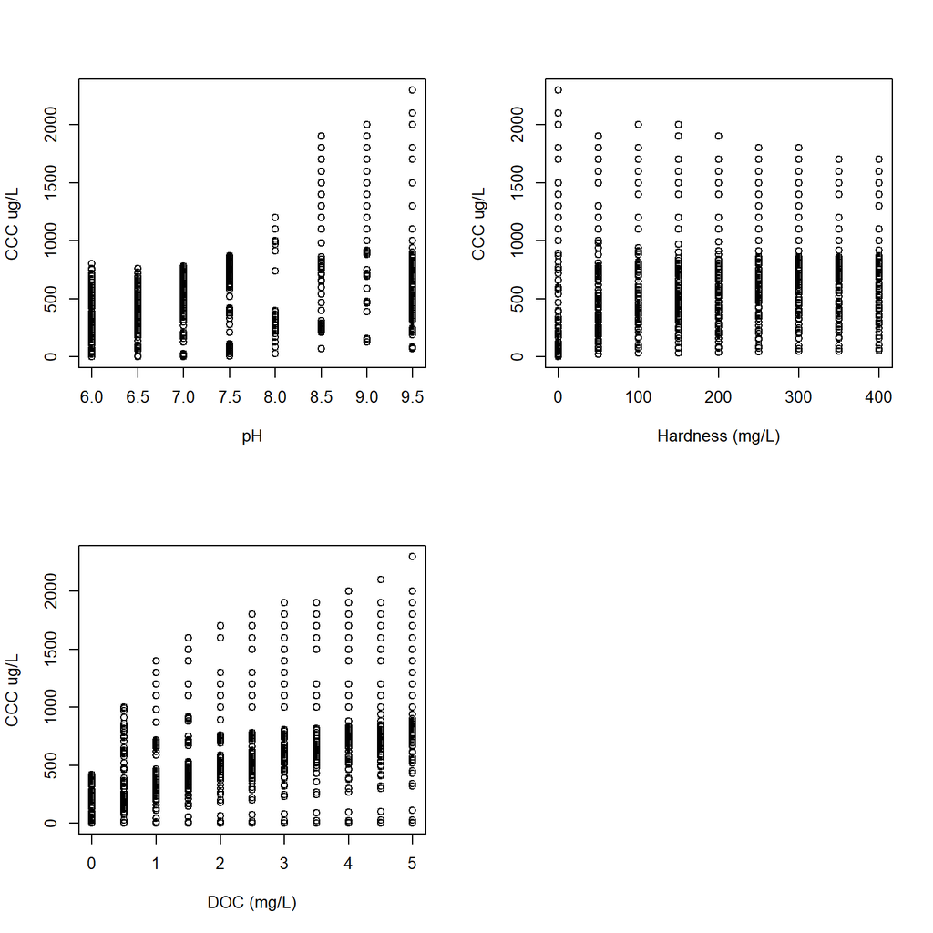

Figure 2. Unmodified CCC variability on correction factors.

# Species deletion & recalculation

Species deleted:  
1. Fatmucket, Lampsilis siliquoidea  
2. Snail, Melanoides tuberculata

## Modify tox table

```r
tox_table_mod=dget('dput_tox_tables.txt')
tox_table_mod=subset(tox_table_mod, !Species %in% c('Fatmucket, Lampsilis siliquoidea', 'Snail, Melanoides tuberculata'))
```

## Calculate modified criteria

```r
mod_crit=calcAlCrit(test_data, 'pH', 'Hardness_mgL', 'DOC_mgL', tox_table=tox_table_mod)
```

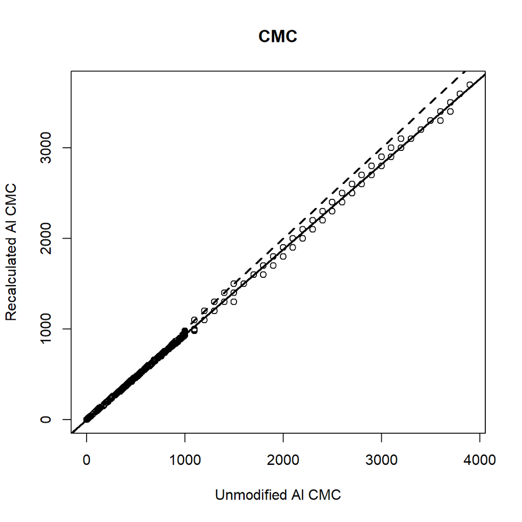

Figure 3. Species deletion modified versus unmodified Al CMC. Dashed line = 1:1 line. Solid line = regression line.

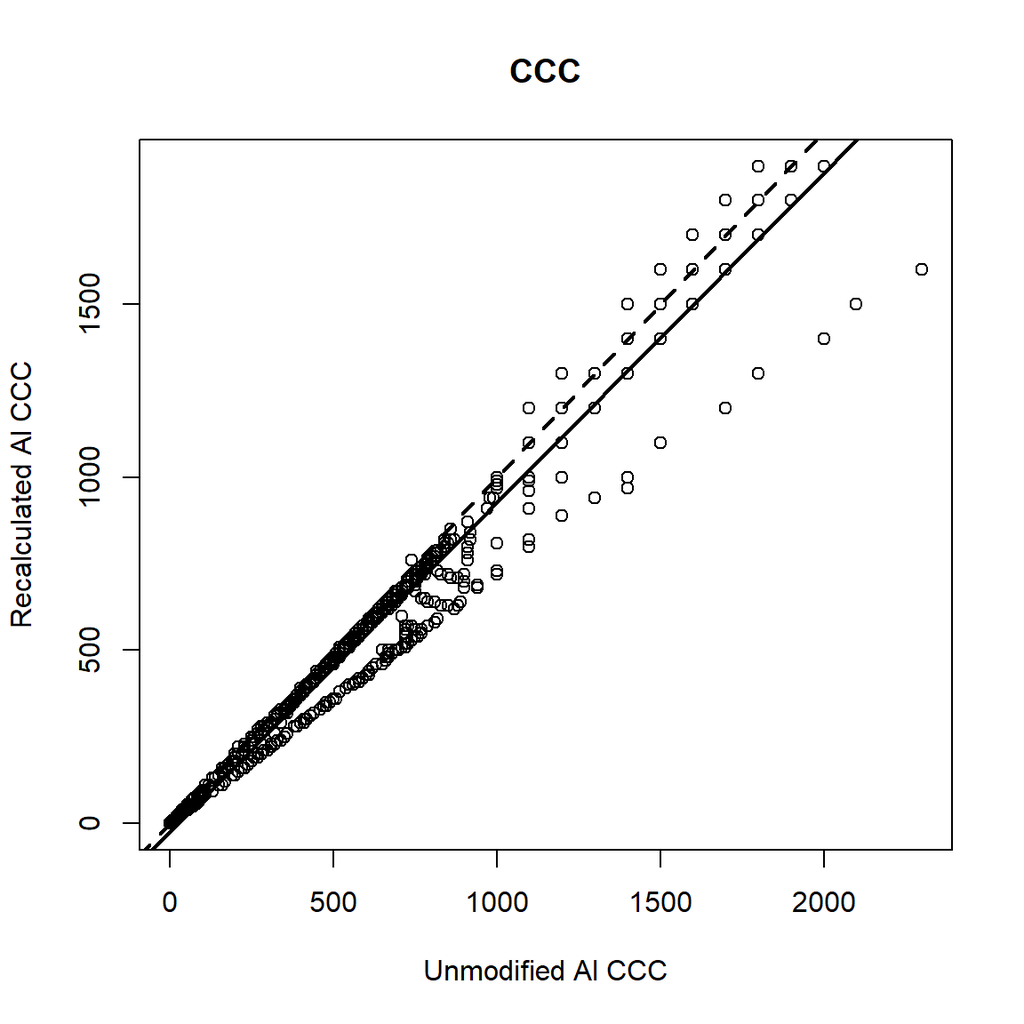

Figure 4. Species deletion modified versus unmodified Al CCC. Dashed line = 1:1 line. Solid line = regression line.

# Discussion points